# 언어심리학을 위한 데이터 사이언스 14-15주차: 말뭉치 #1

고려대학교 일반대학원 심리학과

2022년 6월 13일 월요일 5-6교시

# 1. 대규모 원시 말뭉치 분석을 위한 사전처리

## (1) 말뭉치 자료 데이터베이스

- [세종 말뭉치](https://corpus.korean.go.kr/boards/noticeView.do?page=0&recordId=417&boardId=&base.condition=board.title&base.keyword=%EC%84%B8%EC%A2%85&size=10)
- [표준국어대사전](https://stdict.korean.go.kr/search/searchDetailWords.do): “찾기” $\rightarrow$ “사전 내려받기” 클릭.
- [국립국어원 한국어 학습자 말뭉치](https://kcorpus.korean.go.kr/)
- [국립국어원 모두의 말뭉치](https://corpus.korean.go.kr/main.do)
- [물결21 말뭉치](http://corpus.korea.ac.kr/)
- [AI허브 음성/자연어 데이터베이스](https://aihub.or.kr/aihub-data/natural-language/about)
- [꼬꼬마 프로젝트](http://kkma.snu.ac.kr/)
- Korean Lexicon Project(웹사이트 폐쇄)

## (2) 기존 형태 미분석 말뭉치 자료 활용하기

### A. JSON 파일 자료

#### 1) 단일 파일 불러와 처리하기

- **jsonlite** 패키지의 `fromJSON` 함수를 사용하여 단일 JSON 파일 불러들이기
  - 파일 구조 파악 후 텍스트 자료가 포함된 부분 subsetting하기.
  - 한 파일에 여러 단락 텍스트가 포함되어 있으므로, 해당 단락들을 하나의 데이터 프레임으로 묶어내기.

```r
# 단일 JSON 파일 불러들이기.
library(tidyverse)
library(jsonlite)
json.text <- fromJSON("texts/json/NIRW1900000011.json", simplifyDataFrame =T)

# 파일의 구조를 파악한 뒤 필요한 말뭉치 텍스트 자료가 포함된 부분 subsetting하기.
json.text.1 <- json.text[[3]] %>%
  as_tibble()

# 여러 개의 데이터 프레임으로 구성된 단락 칼럼을 하나의 데이터 프레임으로 전환하기.
json.text.2 <- map_dfr(json.text.1$paragraph, function(x) as_tibble(x))
json.text.2
```

```
## # A tibble: 8,250 x 2
##    id                  form
##    <chr>               <chr>
##  1 NIRW1900000011.1.1  氣운 북돋워 다시 祝배를
##  2 NIRW1900000011.1.2  “위기는 한시적이다. 위기 이후 세계의 질서, 한국 위상이 ~
##  3 NIRW1900000011.1.3  새해가 밝았다. 기축년을 알리는 붉은 해가 솟아올랐지만 경~
##  4 NIRW1900000011.1.4  금융 위기가 실물 경제로 옮겨 붙고, 서민들의 생활고가 현~
##  5 NIRW1900000011.1.5  하지만 모든 기업이 주눅 든 채 웅크리고 있는 것은 아니다.~
##  6 NIRW1900000011.1.6  삼성경제연구소는 “재무 유연성과 소프트 경쟁력이 양호한 ~
##  7 NIRW1900000011.1.7  ◇IT 저력에 한국 경제 달렸다=우리 경제의 희망은 IT에 달~
##  8 NIRW1900000011.1.8  그야말로 IT가 무너지면 우리나라 수출이 무너지고 우리 경~
##  9 NIRW1900000011.1.9  ◇준비하는 기업에 위기는 기회다=국내 산업의 버팀목인 IT ~
## 10 NIRW1900000011.1.10 하지만 전문가들은 위기는 기회라고 말한다. 실제로 2000년 ~
## # ... with 8,240 more rows
```

#### 2) 여러 파일 동시에 불러와 처리하기

- 모든 말뭉치 원자료 파일명에 대한 목록(총 5개 파일) 작성하기.
- 여러 파일 한꺼번에 불러들이기: **purrr**의 `map` 함수를 이용하면 여러 파일을 한꺼번에 불러들일 수 있음.
- 해당 JSON 파일의 구조 살펴보기
  - 3개의 리스트로 구성.
  - 세 번째 리스트에 텍스트를 비롯한 주요 자료 데이터 프레임 포함.
  - 세 번째 리스트의 `paragraph` 열에 텍스트 말뭉치 포함.

```r
# JSON 파일 목록 불러오기.
json.list <- list.files(path = "texts/json", pattern = "json$", recursive = T)
json.list.1 <- paste0("texts/json/", json.list)

# map 함수를 사용하여 목록 내 파일 일괄적으로 읽어들이기.
json.list.2 <- map(json.list.1, function(x) fromJSON(x, simplifyDataFrame = T))

# 5개 JSON 파일에 대해 세 번째 리스트의 paragraph 열만 티블 형식으로 추출하도록 for문 작성.
json_text <- list()
for(i in 1:length(json.list.2)){
  json_text[[i]] <- map_dfr(json.list.2[[i]][[3]]$paragraph, function(x) as_tibble(x))
}

# 리스트 형식으로 추출된 결과물을 티블 형식으로 변환하기.
json_text.1 <- map_dfr(json_text, function(x) as_tibble(x)) %>%
  rename(text = form)
save(json_text.1, file="json_text.1.rda")
json_text.1
```

```
## # A tibble: 35,332 x 2
##    id                  text
##    <chr>               <chr>
##  1 NIRW1900000011.1.1  氣운 북돋워 다시 祝배를
##  2 NIRW1900000011.1.2  “위기는 한시적이다. 위기 이후 세계의 질서, 한국 위상이 ~
##  3 NIRW1900000011.1.3  새해가 밝았다. 기축년을 알리는 붉은 해가 솟아올랐지만 경~
##  4 NIRW1900000011.1.4  금융 위기가 실물 경제로 옮겨 붙고, 서민들의 생활고가 현~
##  5 NIRW1900000011.1.5  하지만 모든 기업이 주눅 든 채 웅크리고 있는 것은 아니다.~
##  6 NIRW1900000011.1.6  삼성경제연구소는 “재무 유연성과 소프트 경쟁력이 양호한 ~
##  7 NIRW1900000011.1.7  ◇IT 저력에 한국 경제 달렸다=우리 경제의 희망은 IT에 달~
##  8 NIRW1900000011.1.8  그야말로 IT가 무너지면 우리나라 수출이 무너지고 우리 경~
##  9 NIRW1900000011.1.9  ◇준비하는 기업에 위기는 기회다=국내 산업의 버팀목인 IT ~
## 10 NIRW1900000011.1.10 하지만 전문가들은 위기는 기회라고 말한다. 실제로 2000년 ~
## # ... with 35,322 more rows
```

### B. XML 파일 자료

#### 1) 단일 파일 불러와 처리하기

- **XML** 패키지의 `xmlParse` 함수를 사용하여 단일 XML 파일 불러들이기
  - 파일 구조 파악 후 텍스트 자료가 포함된 부분 subsetting하기: `header`와 `text` 이렇게 두 노드가 있는데, `text` 노드에 말뭉치 텍스트 자료가 포함되어 있음.
  - 한 파일에 여러 텍스트 단락들이 포함되어 있으므로, 해당 단락들을 하나의 데이터 프레임으로 묶어내기.

```r
# xmlParse 함수를 사용하여 단일 XML 파일 불러들이기.
library(XML)
xml <- xmlParse("texts/sjml/WDRW1900100013.sjml")

# XML 파일 내 "text" 노드를 데이터 프레임으로 변환하기.
xml.df <- xmlToDataFrame(nodes = getNodeSet(xml, "//text")) %>%
  t() %>% # 행을 열로 & 열을 행으로 바꿔주는 R 내장 함수.
  as_tibble() %>%
  rename(text_segment = V1)
xml.df
```

```
## # A tibble: 9 x 1
##   text_segment
##   <chr>
## 1 어제는 아내의 생일이었다. 생일을 맞이하여 아침을 준비하겠다고 오전 8시 30분부~
## 2 주된 메뉴는 스테이크와 낙지볶음, 미역국, 잡채, 소야 등이었다. 스테이크는 자주~
## 3 그런데 상상도 못한 일이 벌이지고 말았다. 보통 시즈닝이 되지 않은 원육을 사서 ~
## 4 앞면을 센불에 1분을 굽고 뒤집는 순간 방부제가 함께 구어진 것을 알았다. 아내의~
## 5 어처구니 없는 상황이 발생한 것이다. 방부제가 센불에 녹아서 그런지 물처럼 흘러~
## 6 방부제가 묻은 부문만 제거 하고 다시 구울까 했는데 방부제에 절대 먹지 말라는 ~
## 7 하지만 정신을 추스리고 바로 다른 메뉴로 변경했다. 소야, 소세지 야채볶음... 아~
## 8 음식은 성공적으로 완성이 되었다. 40번째를 맞이하는 아내의 생일은 성공적으로 ~
## 9 오늘도 즐거운 하루가 되었으면 좋겠다. 생일이니까~
```

#### 2) 여러 파일 동시에 불러와 처리하기

```r
# XML 파일 목록 불러오기.
xml.list <- list.files(path = "texts/sjml", pattern = "sjml$", recursive = T)
xml.list.1 <- paste0("texts/sjml/", xml.list)

# 목록 내 XML 파일 일괄적으로 읽어들이는 함수 자체 제작하기.
xml.import <- function(sjml){
  x <- read_lines(sjml) %>% # tidyverse의 read_lines 함수로 먼저 불러들이기.
    str_replace_all(" > |&", "") %>% # 일괄적으로 XML 파일을 읽어들일 때
                                     # 문제가 되는 기호 ">", "&"(ampersand) 제거하기.
    xmlParse() # XML 파일 parsing하기.
  y <- xmlToDataFrame(nodes = getNodeSet(x, "//text")) %>% # "text" 노드만 선택하여
                                                           # 데이터 프레임으로 변환하기.
    t() %>% # 행을 열로 & 열을 행으로 바꿔주는 R 내장 함수.
    as_tibble() %>%
    rename(text_segment = V1)
  y
}

# 자체 제작 함수 xml.import를 사용하여 목록 내 XML 파일 티블 형식으로 일괄 변환하기.
xml.import.1 <- map_dfr(xml.list.1, function(x) xml.import(x))
xml.import.1
```

```
## # A tibble: 3,621 x 1
##    text_segment
##    <chr>
##  1 어제는 아내의 생일이었다. 생일을 맞이하여 아침을 준비하겠다고 오전 8시 30분~
##  2 주된 메뉴는 스테이크와 낙지볶음, 미역국, 잡채, 소야 등이었다. 스테이크는 자~
##  3 그런데 상상도 못한 일이 벌이지고 말았다. 보통 시즈닝이 되지 않은 원육을 사서~
##  4 앞면을 센불에 1분을 굽고 뒤집는 순간 방부제가 함께 구어진 것을 알았다. 아내~
##  5 어처구니 없는 상황이 발생한 것이다. 방부제가 센불에 녹아서 그런지 물처럼 흘~
##  6 방부제가 묻은 부문만 제거 하고 다시 구울까 했는데 방부제에 절대 먹지 말라는 ~
##  7 하지만 정신을 추스리고 바로 다른 메뉴로 변경했다. 소야, 소세지 야채볶음... ~
##  8 음식은 성공적으로 완성이 되었다. 40번째를 맞이하는 아내의 생일은 성공적으로 ~
##  9 오늘도 즐거운 하루가 되었으면 좋겠다. 생일이니까~
## 10 나는소금이 나오는 게곡에 가보고 싶어진다.
## # ... with 3,611 more rows
```

```r
save(xml.import.1, file="xml.import.1.rda")
```

# 2. 대규모 원시 말뭉치 형태분석 시행하기

## (1) **KoNLP** 패키지 사용하기

- 개관
  - 전희원 프로그래머에 의해 개발된 R 기반 한국어 자연어 처리 패키지. 총 27개의 함수가 포함되어 있음.
  - 2020년 2월 1일 이후로 업데이트가 중단됨. CRAN에서도 삭제된 상태이므로, `install.packages` 함수로는 설치 불가.

### A. **KoNLP** 패키지 설치하기

**1.** [Rtools40](https://cran.r-project.org/bin/windows/Rtools/index.html) 설치하기.

**2.** **java** 프로그램과 **rjava** 패키지 설치하기.

```r
install.packages("multilinguer")
library(multilinguer)
install_jdk()
```

**3.** 의존성 패키지 설치하기.

```r
install.packages(c("hash", "tau", "Sejong", "RSQLite", "devtools", "bit", "rex",
                   "lazyeval", "htmlwidgets", "crosstalk", "promises", "later",
                   "sessioninfo", "xopen", "bit64", "blob", "DBI", "memoise",
                   "plogr", "covr", "DT", "rcmdcheck", "rversions"),
                 type = "binary")
```

**4.** **KoNKP** 패키지 설치하기.

```r
library(devtools)
install_github('haven-jeon/KoNLP', upgrade = "never", INSTALL_opts=c("--no-multiarch"))
```

### B. 형태 미분석 문자열 대상으로 형태분석 시행하기

- 주요 함수 I
  - `useSejongDic()`: **KoNLP** 패키지 사용을 위해 세종 말뭉치 기반 사전 불러오기.
  - `SimplePos09`
    - KAIST 9품사 태그셋에 기초한 형태분석 시행.
    - 입력: 문자열만 가능.
    - 출력: 결과를 리스트로 반환.
    - 논항: `autoSpacing = T`를 추가하면 띄어쓰기를 자동으로 해줌. 그러나 성능이 뛰어나지는 않음.
  - `SimplePos22`
    - KAIST 22품사 태그셋에 기초한 형태분석 시행.
    - 입력: 문자열만 가능.
    - 출력: 결과를 리스트로 반환.
    - 논항: `autoSpacing = T`를 추가하면 띄어쓰기를 자동으로 해줌. 그러나 성능이 뛰어나지는 않음.

**[그림 1] KAIST 품사 태그셋**

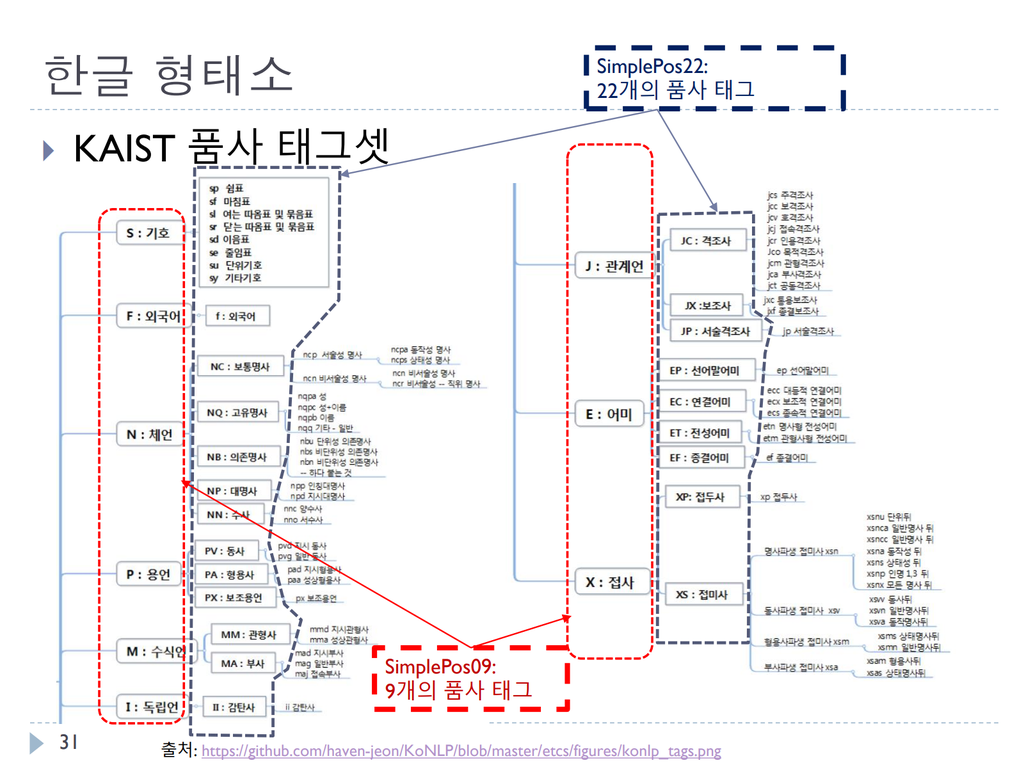

```r
library(KoNLP)

# 세종 말뭉치 기반 사전 불러오기. KoNLP 패키지를 사용하려면 반드시 먼저 사전을 불러와야 함.
useSejongDic()
```

```
## Backup was just finished!
## 370957 words dictionary was built.
```

```r
# 문자열 만들기.
string1 <- "어제는 아내의 생일이었다. 생일을 맞이하여 아침을 준비하겠다고 오전 8시 30분부터 음식을 준비하였다."

# SimplePos09 함수로 문자열 형태소 분석하기.
SimplePos09(string1) %>%
  unlist()
```

```
##                    어제는                    아내의                생일이었다
##             "어제/N+는/J"             "아내/N+의/J"      "생일/N+이/J+었다/E"
##                         .                    생일을                  맞이하여
##                     "./S"             "생일/N+을/J"        "맞이/N+하/X+어/E"
##                    아침을              준비하겠다고                      오전
##             "아침/N+을/J" "준비/N+하/X+겠다/E+고/J"                  "오전/N"
##                       8시                  30분부터                    음식을
##                   "8시/N"           "30분/N+부터/J"             "음식/N+을/J"
##                준비하였다                         .
##      "준비/N+하/X+었다/E"                     "./S"
```

```r
# SimplePos22 함수로 문자열 형태소 분석하기.
SimplePos22(string1) %>%
  unlist()
```

```
##                            어제는                            아내의
##                   "어제/NC+는/JX"                   "아내/NC+의/JC"
##                        생일이었다                                 .
##       "생일/NC+이/JP+었/EP+다/EF"                            "./SF"
##                            생일을                          맞이하여
##                   "생일/NC+을/JC"             "맞이/NC+하/XS+어/EC"
##                            아침을                      준비하겠다고
##                   "아침/NC+을/JC" "준비/NC+하/XS+겠/EP+다/EF+고/JC"
##                              오전                               8시
##                         "오전/NC"                      "8/NN+시/NB"
##                          30분부터                            음식을
##             "30/NN+분/NB+부터/JX"                   "음식/NC+을/JC"
##                        준비하였다                                 .
##       "준비/NC+하/XS+었/EP+다/EF"                            "./SF"
```

```r
# SimplePos22 함수를 사용하여 문자열을 형태분석해주는 자체 제착 함수 만들기.
unlist_pos22 <- function(string){
  string %>%
    SimplePos22(autoSpacing = T) %>%
    unlist()
}

# 자체 제작 함수 unlist_pos22에 string1 문자열 투입하기.
unlist_pos22(string1)
```

```
##                            어제는                            아내의
##                   "어제/NC+는/JX"                   "아내/NC+의/JC"
##                        생일이었다                                 .
##       "생일/NC+이/JP+었/EP+다/EF"                            "./SF"
##                            생일을                            맞이하
##                   "생일/NC+을/JC"             "맞이/NC+하/XS+어/EC"
##                                여                            아침을
##                           "여/NC"                   "아침/NC+을/JC"
##                      준비하겠다고                              오전
## "준비/NC+하/XS+겠/EP+다/EF+고/JC"                         "오전/NC"
##                               8시                          30분부터
##                      "8/NN+시/NB"             "30/NN+분/NB+부터/JX"
##                            음식을                        준비하였다
##                   "음식/NC+을/JC"       "준비/NC+하/XS+었/EP+다/EF"
##                                 .
##                            "./SF"
```

```r
# SimplePos22 함수를 사용한 형태소 분석 및 빈도 계산 사례.
string1 %>%
  SimplePos22() %>%
  flatten_dfc() %>% # 1행으로 이루어진 티블로 만들기.
  pivot_longer(everything(), names_to = "header", values_to = "value") %>% # 열과 행 방향을 바꾸고, header와 value 열 만들기.
  separate_rows(value, sep = "\\+") %>% # "+" 기호를 기준으로 행 단위로 분절하기.
  separate(value, into = c("word", "pos"), sep = "/") %>% # "/" 기호를 기준으로 word와 pos 열로 나누기.
  count(word, sort = T) %>% # word 열의 형태소 빈도 계산하기.
  filter(str_length(word) > 1) # word 열의 형태소 중 길이가 2음절 이상인 것만 필터링하기.
```

```
## # A tibble: 10 x 2
##    word      n
##    <chr> <int>
##  1 생일      2
##  2 준비      2
##  3 30        1
##  4 맞이      1
##  5 부터      1
##  6 아내      1
##  7 아침      1
##  8 어제      1
##  9 오전      1
## 10 음식      1
```

- 주요 함수 II
  - `extractNoun`
    - 명사만 추출해줌.
    - 입력: 문자열 벡터.
    - 출력
      - 입력이 문자열일 경우, 결과를 벡터로 반환.
      - 입력이 벡터일 경우, 리스트(한 문장 당 리스트 하나)로 반환.
  - `MorphAnalyzer`
    - 정밀한 형태분석을 실행해줌.
    - 단, 결과가 반환될 때 가능한 여러 선택지가 동시에 제공됨.
    - 입력: 문자열 스칼라만 가능.
    - 출력: 결과를 리스트로 반환.
  - `convertHangulStringToJamos`
    - 한글 문자열을 자모 단위로 분해해줌.
    - 입력: 문자열 스칼라만 가능.
    - 출력
      - 결과를 벡터로 반환.
      - 단, 모음 앞의 “ㅇ”과 자음 “ㅇ”의 구분이 없음.
  - `HangulAutomata`
    - 자모 분해된 한글 문자열을 음절 단위 문자열로 복원해줌.
    - 입력: 문자열 스칼라만 가능.
    - 출력: 결과를 벡터로 반환.
  - `is.hangul`
    - 문자열이 한글인지 여부를 판정해줌.
    - 입력: 문자열 벡터.
    - 출력: 결과를 논리형으로 반환.

```r
# 명사만 추출하기.
extractNoun(string1)
```

```
##  [1] "어제" "아내" "생일" "생일" "맞이" "아침" "준비" "오전" "8"    "시"
## [11] "30"   "분"   "음식" "준비"
```

```r
# 정밀한 형태소 분석 시행하기.
MorphAnalyzer(string1)
```

```
## $어제는
## [1] "어제/ncn+는/jxc"
##
## $아내의
## [1] "아내/ncn+의/jcm" "아내/ncn+의/ncn"
##
## $생일이었다
## [1] "생일/ncn+이/jp+었/ep+다/ef"        "생일/ncn+이/ncn+이/jp+었/ep+다/ef"
##
## $.
## [1] "./sf" "./sy"
##
## $생일을
## [1] "생일/ncn+을/jco"
##
## $맞이하여
## [1] "맞이/ncpa+하/xsva+어/ecs" "맞이/ncpa+하/xsva+어/ecx"
## [3] "맞이/ncpa+하/xsva+어/ef"
##
## $아침을
## [1] "아침/ncn+을/jco"
##
## $준비하겠다고
## [1] "준비/ncpa+하/xsva+겠/ep+다고/ecs"
## [2] "준비/ncpa+하/xsva+겠/ep+다고/ecx"
## [3] "준비/ncpa+하/xsva+겠/ep+다고/ef"
## [4] "준비/ncpa+하/xsva+겠/ep+다/ef+고/jcr"
## [5] "준비/ncps+하/xsms+겠/ep+다고/ecs"
## [6] "준비/ncps+하/xsms+겠/ep+다고/ecx"
## [7] "준비/ncps+하/xsms+겠/ep+다고/ef"
## [8] "준비/ncps+하/xsms+겠/ep+다/ef+고/jcr"
##
## $오전
## [1] "오전/ncn"       "오/ncn+전/xsnx" "오/nnc+전/nbu"  "오/nnc+전/xsnx"
##
## $`8시`
## [1] "8/nnc+시/nbu"
##
## $`30분부터`
## [1] "30/nnc+분/nbu+부터/jca" "30/nnc+분/nbu+부터/jxc"
##
## $음식을
## [1] "음식/ncn+을/jco"        "음/ncn+식/xsncc+을/jco"
##
## $준비하였다
## [1] "준비/ncpa+하/xsva+었/ep+다/ef" "준비/ncps+하/xsms+었/ep+다/ef"
##
## $.
## [1] "./sf" "./sy"
```

```r
# 문자열을 자모 단위로 분해하기.
s1 <- convertHangulStringToJamos(string1)
s1
```

```
##  [1] "ㅇㅓ"   "ㅈㅔ"   "ㄴㅡㄴ" " "      "ㅇㅏ"   "ㄴㅐ"   "ㅇㅢ"   " "
##  [9] "ㅅㅐㅇ" "ㅇㅣㄹ" "ㅇㅣ"   "ㅇㅓㅆ" "ㄷㅏ"   "."      " "      "ㅅㅐㅇ"
## [17] "ㅇㅣㄹ" "ㅇㅡㄹ" " "      "ㅁㅏㅈ" "ㅇㅣ"   "ㅎㅏ"   "ㅇㅕ"   " "
## [25] "ㅇㅏ"   "ㅊㅣㅁ" "ㅇㅡㄹ" " "      "ㅈㅜㄴ" "ㅂㅣ"   "ㅎㅏ"   "ㄱㅔㅆ"
## [33] "ㄷㅏ"   "ㄱㅗ"   " "      "ㅇㅗ"   "ㅈㅓㄴ" " "      "8"      "ㅅㅣ"
## [41] " "      "3"      "0"      "ㅂㅜㄴ" "ㅂㅜ"   "ㅌㅓ"   " "      "ㅇㅡㅁ"
## [49] "ㅅㅣㄱ" "ㅇㅡㄹ" " "      "ㅈㅜㄴ" "ㅂㅣ"   "ㅎㅏ"   "ㅇㅕㅆ" "ㄷㅏ"
## [57] "."
```

```r
# 자모 단위로 문자열 분해하기.
str_c(s1, collapse = "")
```

```
## [1] "ㅇㅓㅈㅔㄴㅡㄴ ㅇㅏㄴㅐㅇㅢ ㅅㅐㅇㅇㅣㄹㅇㅣㅇㅓㅆㄷㅏ. ㅅㅐㅇㅇㅣㄹㅇㅡㄹ ㅁㅏㅈㅇㅣㅎㅏㅇㅕ ㅇㅏㅊㅣㅁㅇㅡㄹ ㅈㅜㄴㅂㅣㅎㅏㄱㅔㅆㄷㅏㄱㅗ ㅇㅗㅈㅓㄴ 8ㅅㅣ 30ㅂㅜㄴㅂㅜㅌㅓ ㅇㅡㅁㅅㅣㄱㅇㅡㄹ ㅈㅜㄴㅂㅣㅎㅏㅇㅕㅆㄷㅏ."
```

```r
# 자모 단위로 분해된 문자열을 음절 단위 문자열로 복원하기.
str_c(s1, collapse = "") %>%
  HangulAutomata()
```

```
## [1] "어제는 아내의 생일이었다. 생일을 맞이하여 아침을 준비하겠다고 오전 8시 30분부터 음식을 준비하였다."
```

```r
pos.string <- c("어제", "는", "아내", "의", "생일", "이", "었", "다", ".",
                "생일", "을", "맞이", "하", "여", "아침", "을", "준비", "하",
                "겠", "다고", "오전", "8", "시", "30", "분", "부터", "음식",
                "을", "준비", "하", "였", "다", ".")

# convertHangulStringToJamos 함수를 사용한 자모분해 실습.
string.to.jamo <- map(pos.string, function(x) convertHangulStringToJamos(x)) %>%
  map(function(x) str_c(x, collapse = "")) %>%
  unlist() %>%
  as_tibble() %>%
  rename(jamo = value) %>%
  mutate(token = pos.string,
         jamo_TF = is.hangul(jamo)) %>%
  filter(jamo_TF == T) %>%
  select(token, jamo, -jamo_TF)
string.to.jamo
```

```
## # A tibble: 29 x 2
##    token jamo
##    <chr> <chr>
##  1 어제  ㅇㅓㅈㅔ
##  2 는    ㄴㅡㄴ
##  3 아내  ㅇㅏㄴㅐ
##  4 의    ㅇㅢ
##  5 생일  ㅅㅐㅇㅇㅣㄹ
##  6 이    ㅇㅣ
##  7 었    ㅇㅓㅆ
##  8 다    ㄷㅏ
##  9 생일  ㅅㅐㅇㅇㅣㄹ
## 10 을    ㅇㅡㄹ
## # ... with 19 more rows
```

```r
# convertHangulStringToJamos 함수를 사용한 자모분해 자체 제작 함수 만들기.
string_to_jamo <- function(string_vector){
  map(string_vector, function(x) convertHangulStringToJamos(x)) %>%
    map(function(x) str_c(x, collapse = "")) %>%
    unlist() %>%
    as_tibble() %>%
    rename(jamo = value) %>%
    mutate(token = string_vector,
           jamo_TF = is.hangul(jamo)) %>%
    filter(jamo_TF == T) %>%
    select(token, jamo, -jamo_TF) %>%
    unique()
}
string1.jamo <- string_to_jamo(pos.string)
string1.jamo
```

```
## # A tibble: 22 x 2
##    token jamo
##    <chr> <chr>
##  1 어제  ㅇㅓㅈㅔ
##  2 는    ㄴㅡㄴ
##  3 아내  ㅇㅏㄴㅐ
##  4 의    ㅇㅢ
##  5 생일  ㅅㅐㅇㅇㅣㄹ
##  6 이    ㅇㅣ
##  7 었    ㅇㅓㅆ
##  8 다    ㄷㅏ
##  9 을    ㅇㅡㄹ
## 10 맞이  ㅁㅏㅈㅇㅣ
## # ... with 12 more rows
```

## (2) **RcppMeCab** 및 **RmecabKo** 패키지 사용하기

- 개관
  - 오픈소스 형태소 분석기인 `MeCab`을 R 환경에서 사용할 수 있도록 만든 패키지.
  - **Rcpp** 패키지를 사용하여 **C++**에서 직접 연산을 수행하므로, R에서 제공되는 어떤 형태소 분석기보다 속도가 빠름.
  - 분산처리 함수를 활용한 다중 스레딩(multi-threading) 처리도 제공하므로, 대량의 자료를 빠르게 분석하는 데 적합.

### A. **RcppMeCab** 및 **RmecabKo** 패키지 설치하기

#### 1) 윈도 사용자

**1.** **RcppMeCab** 및 **RmecabKo** 패키지 설치하기.

```r
# CRAN을 통해 설치하기.
install.packages("RcppMeCab") # 현재 CRAN 버전은 Rcpp 지원이 늦어 업그레이드를 못하고 있다고 함.
install.packages("RmecabKo")

# github를 통해 설치하기.
library(devtools)
install_github("junhewk/RcppMeCab")
install_github("junhewk/RmecabKo")
```

**2.** `MeCab` 프로그램과 사전 설치하기

- `MeCab` 프로그램: [mecab-ko-0.9.2-msvc-3](https://github.com/Pusnow/mecab-ko-msvc/releases/download/release-0.9.2-msvc-3/mecab-ko-msvc-x64.zip)
- `MeCab` 사전: [mecab-ko-dic-2.1.1-20180720-msvc-2](https://github.com/Pusnow/mecab-ko-dic-msvc/releases/download/mecab-ko-dic-2.1.1-20180720-msvc-2/mecab-ko-dic-msvc.zip)
- 디렉토리에 압축 해제하기
  - 두 압축파일을 받아 `C:\mecab` 디렉토리에 압축해체.
  - `C:\mecab`에 `mecabrc` 파일과 `mecab-ko-dic` 디렉토리가 있어야 함.

#### 2) 맥 사용자

**1.** `MeCab` 프로그램과 사전 설치하기

- `MeCab` 프로그램: mecab-0.996-ko-0.9.2.tar.gz
- `MeCab` 사전: mecab-ko-dic-2.1.1-20180720.tar.gz
- 터미널 쉘에서 아래의 코드 실행하기.

```bash
# MeCab 프로그램 설치하기.
$ wget https://bitbucket.org/eunjeon/mecab-ko/downloads/mecab-0.996-ko-0.9.2.tar.gz
$ tar xzvf mecab-0.996-ko-0.9.2.tar.gz
$ cd mecab-0.996-ko-0.9.2
$ ./configure
$ make
$ sudo make install

# MeCab 사전 설치하기.
$ wget https://bitbucket.org/eunjeon/mecab-ko-dic/downloads/mecab-ko-dic-2.1.1-20180720.tar.gz
$ tar xzvf mecab-ko-dic-2.1.1-20180720.tar.gz
$ cd mecab-0.996-ko-0.9.2
$ ./configure
$ make
$ sudo make install
```

**2.** **RcppMeCab** 및 **RmecabKo** 패키지 설치하기.

```r
# CRAN을 통해 설치하기.
install.packages("RcppMeCab") # 현재 CRAN 버전은 Rcpp 지원이 늦어 업그레이드를 못하고 있다고 함.
install.packages("RmecabKo")

# github를 통해 설치하기.
library(devtools)
install_github("junhewk/RcppMeCab")
install_github("junhewk/RmecabKo")
```

### B. 형태 미분석 문자열 대상으로 형태분석 시행하기

- **RcppMeCab** 패키지
  - `pos` 함수
    - 개관
      - 기본 형태소 분석 함수. 문자열 벡터를 분석하여 형태소 태그를 부착해줌.
      - 장점: 띄어쓰기가 불완전해도 알아서 어절 단위로 분할해줌.
      - 단점: 용언 + 어미 어절은 형태소 태그를 부착해주나, 둘을 분해해주지는 않음.
    - 논항
      - `join = T`: 디폴트가 `TRUE`임. “형태소/품사” 형태로 결과 반환.
      - `format = data.frame`
        - 디폴트가 리스트임. 데이터 프레임 형식으로 결과 반환.
        - `analytic`이라는 열에서 용언 + 어미 어절을 분해해줌.
  - `posParrell` 함수
    - `pos`와 같은 기능을 수행하지만, 다중 스레딩을 지원해줌.
    - 속도는 빠르나, 그만큼 메모리 소모도 많음.
    - 논항은 `pos`와 동일.

```r
library(RcppMeCab)
library(RmecabKo)
string <- c("안녕하세요반갑습니다많은이용부탁드립니다", "오늘은아내의생일이다.")

# 형태소 태그 부착하기: pos 함수 사용하기.
string %>%
  enc2utf8() %>%
  RcppMeCab::pos(format = "data.frame")
```

```
##    doc_id sentence_id token_id    token   pos subtype              analytic
## 1       1           1        1     안녕   NNG    행위
## 2       1           1        2       하   XSV
## 3       1           1        3     세요 EP+EF             시/EP/*+어요/EF/*
## 4       1           1        4     반갑    VA
## 5       1           1        5   습니다    EF
## 6       1           1        6       많    VA
## 7       1           1        7       은   ETM
## 8       1           1        8     이용   NNG
## 9       1           1        9     부탁   NNG    행위
## 10      1           1       10 드립니다 VV+EC         드리/VV/*+ㅂ니다/EC/*
## 11      2           1        1     오늘   NNG
## 12      2           1        2       은    JX
## 13      2           1        3     아내   NNG
## 14      2           1        4       의   JKG
## 15      2           1        5     생일   NNG
## 16      2           1        6       이   VCP
## 17      2           1        7       다    EF
## 18      2           1        8        .    SF
```

```r
# 형태소 태그 부착하기: posParallel 함수 사용하기.
string %>%
  enc2utf8() %>%
  posParallel(format = "data.frame")
```

```
##    doc_id sentence_id token_id    token   pos subtype              analytic
## 1       1           1        1     안녕   NNG    행위
## 2       1           1        2       하   XSV
## 3       1           1        3     세요 EP+EF             시/EP/*+어요/EF/*
## 4       1           1        4     반갑    VA
## 5       1           1        5   습니다    EF
## 6       1           1        6       많    VA
## 7       1           1        7       은   ETM
## 8       1           1        8     이용   NNG
## 9       1           1        9     부탁   NNG    행위
## 10      1           1       10 드립니다 VV+EC         드리/VV/*+ㅂ니다/EC/*
## 11      2           1        1     오늘   NNG
## 12      2           1        2       은    JX
## 13      2           1        3     아내   NNG
## 14      2           1        4       의   JKG
## 15      2           1        5     생일   NNG
## 16      2           1        6       이   VCP
## 17      2           1        7       다    EF
## 18      2           1        8        .    SF
```

- `analytic` 열의 추가 형태소 분석 정보를 이용하여 용언 + 어미 어절까지 완벽하게 분해하기.

```r
# RcppMeCab 패키지의 pos 함수로 문자열 형태소 분석하기.
s1 <- string %>%
  enc2utf8() %>%
  RcppMeCab::pos()

# 리스트 형식의 문자열 형태분석 결과를 티블 형식로 변환하기
y <- map_dfr(s1, function(x) as_tibble(x))

# analytic 열의 정보를 이용하여 용언 + 어미 어절까지 분해하기.
string_analyzed <- string %>%
  enc2utf8() %>%
  RcppMeCab::pos(format = "data.frame") %>%
  bind_cols(y) %>%
  mutate(
    analytic = str_replace_all(analytic, "\\/\\*\\+|\\/[ㄱ-ㅎ가-힣]{1,100}\\+", "\\/\\+"),
    analytic = str_replace_all(analytic,  "\\/\\*$|\\/[ㄱ-ㅎ가-힣]{1,100}\\$", ""),
    ej_tagged = case_when(str_length(analytic) == 0 ~ value,
                          T ~ analytic)
    ) %>%
  separate_rows(ej_tagged, sep = "\\+")
string_analyzed
```

```
## # A tibble: 20 x 9
##    doc_id sentence_id token_id token    pos   subtype analytic   value ej_tagged
##    <chr>        <int>    <int> <chr>    <chr> <chr>   <chr>      <chr> <chr>
##  1 1                1        1 안녕     NNG   "행위"  ""         안녕~ 안녕/NNG
##  2 1                1        2 하       XSV   ""      ""         하/X~ 하/XSV
##  3 1                1        3 세요     EP+EF ""      "시/EP/+~  세요~ 시/EP/
##  4 1                1        3 세요     EP+EF ""      "시/EP/+~  세요~ 어요/EF
##  5 1                1        4 반갑     VA    ""      ""         반갑~ 반갑/VA
##  6 1                1        5 습니다   EF    ""      ""         습니~ 습니다/EF
##  7 1                1        6 많       VA    ""      ""         많/VA 많/VA
##  8 1                1        7 은       ETM   ""      ""         은/E~ 은/ETM
##  9 1                1        8 이용     NNG   ""      ""         이용~ 이용/NNG
## 10 1                1        9 부탁     NNG   "행위"  ""         부탁~ 부탁/NNG
## 11 1                1       10 드립니다 VV+EC ""      "드리/VV/~ 드립~ 드리/VV/
## 12 1                1       10 드립니다 VV+EC ""      "드리/VV/~ 드립~ ㅂ니다/EC
## 13 2                1        1 오늘     NNG   ""      ""         오늘~ 오늘/NNG
## 14 2                1        2 은       JX    ""      ""         은/JX 은/JX
## 15 2                1        3 아내     NNG   ""      ""         아내~ 아내/NNG
## 16 2                1        4 의       JKG   ""      ""         의/J~ 의/JKG
## 17 2                1        5 생일     NNG   ""      ""         생일~ 생일/NNG
## 18 2                1        6 이       VCP   ""      ""         이/V~ 이/VCP
## 19 2                1        7 다       EF    ""      ""         다/EF 다/EF
## 20 2                1        8 .        SF    ""      ""         ./SF  ./SF
```

```r
# analytic 열의 정보를 이용하여 용언 + 어미 어절까지 분해해주는 자체 제작 함수 만들기.
pos_analytic <- function(string_vector){
  a <- string_vector %>%
    enc2utf8() %>%
    posParallel()
  x1 <- map_dfr(a, function(x) as_tibble(x))
  b <- string_vector %>%
    enc2utf8() %>%
    posParallel(format = "data.frame") %>%
    bind_cols(x1) %>%
    mutate(
      analytic = str_replace_all(analytic,
                                 "\\/\\*\\+|\\/[ㄱ-ㅎ가-힣]{1,100}\\+", "\\/\\+"),
      analytic = str_replace_all(analytic,
                                 "\\/\\*$|\\/[ㄱ-ㅎ가-힣]{1,100}\\$", ""),
      ej_tagged = case_when(str_length(analytic) == 0 ~ value,
                            T ~ analytic)
    ) %>%
    separate_rows(ej_tagged, sep = "\\+")
  b
}
string_analyzed_by_func <- pos_analytic(string)
string_analyzed_by_func
```

```
## # A tibble: 20 x 9
##    doc_id sentence_id token_id token    pos   subtype analytic   value ej_tagged
##    <chr>        <int>    <int> <chr>    <chr> <chr>   <chr>      <chr> <chr>
##  1 1                1        1 안녕     NNG   "행위"  ""         안녕~ 안녕/NNG
##  2 1                1        2 하       XSV   ""      ""         하/X~ 하/XSV
##  3 1                1        3 세요     EP+EF ""      "시/EP/+~  세요~ 시/EP/
##  4 1                1        3 세요     EP+EF ""      "시/EP/+~  세요~ 어요/EF
##  5 1                1        4 반갑     VA    ""      ""         반갑~ 반갑/VA
##  6 1                1        5 습니다   EF    ""      ""         습니~ 습니다/EF
##  7 1                1        6 많       VA    ""      ""         많/VA 많/VA
##  8 1                1        7 은       ETM   ""      ""         은/E~ 은/ETM
##  9 1                1        8 이용     NNG   ""      ""         이용~ 이용/NNG
## 10 1                1        9 부탁     NNG   "행위"  ""         부탁~ 부탁/NNG
## 11 1                1       10 드립니다 VV+EC ""      "드리/VV/~ 드립~ 드리/VV/
## 12 1                1       10 드립니다 VV+EC ""      "드리/VV/~ 드립~ ㅂ니다/EC
## 13 2                1        1 오늘     NNG   ""      ""         오늘~ 오늘/NNG
## 14 2                1        2 은       JX    ""      ""         은/JX 은/JX
## 15 2                1        3 아내     NNG   ""      ""         아내~ 아내/NNG
## 16 2                1        4 의       JKG   ""      ""         의/J~ 의/JKG
## 17 2                1        5 생일     NNG   ""      ""         생일~ 생일/NNG
## 18 2                1        6 이       VCP   ""      ""         이/V~ 이/VCP
## 19 2                1        7 다       EF    ""      ""         다/EF 다/EF
## 20 2                1        8 .        SF    ""      ""         ./SF  ./SF
```

- **tidytext** 패키지의 `unnest_token` 함수를 이용하여 tokenizing하기
  - `output`: tokenzing의 결과 열.
  - `input`: tokenizing에 투입될 입력.
  - `token`: words(디폴트), characters, character_shingles, ngrams, skip_ngrams, sentences, lines, paragraphs, regex, tweets 등의 선택지가 있음.
  - `drop`: input(입력)을 그대로 놓아둘 것인지 여부를 결정. `drop = TRUE`가 디폴트, 즉 입력은 생략하고 결과 열만 남김.

> unnest_tokens(output = tokenzing의 결과물, input = tokenzing에 투입될 입력, token = tokenizing 방법)

```r
library(tidytext)
string %>%
  enc2utf8() %>%
  tibble(text = .) %>%
  unnest_tokens(output = morpheme, input = text, token = RcppMeCab::pos)
```

```
## # A tibble: 18 x 1
##    morpheme
##    <chr>
##  1 안녕/nng
##  2 하/xsv
##  3 세요/ep+ef
##  4 반갑/va
##  5 습니다/ef
##  6 많/va
##  7 은/etm
##  8 이용/nng
##  9 부탁/nng
## 10 드립니다/vv+ec
## 11 오늘/nng
## 12 은/jx
## 13 아내/nng
## 14 의/jkg
## 15 생일/nng
## 16 이/vcp
## 17 다/ef
## 18 ./sf
```

- **RmecabKo** 패키지
  - `pos` 함수: **RcppMeCab** 패키지와 동일. 단, `format` 논항은 사용되지 않음.
  - `nouns` 함수: 문자열 벡터에서 명사만 추출해줌.
  - `token_morph`: 문자열 벡터를 형태소 단위로 분석해줌.
  - `token_words`: 문자열 벡터를 단어 단위로 분석해줌.

```r
# pos 함수로 문자열 스칼라 형태소 분석하기.
pos(string[1])
```

```
## $안녕하세요반갑습니다많은이용부탁드립니다
##  [1] "안녕/NNG"       "하/XSV"         "세요/EP+EF"     "반갑/VA"
##  [5] "습니다/EF"      "많/VA"          "은/ETM"         "이용/NNG"
##  [9] "부탁/NNG"       "드립니다/VV+EC"
```

```r
# pos 함수로 문자열 벡터 형태소 분석하기.
pos(string)
```

```
## $안녕하세요반갑습니다많은이용부탁드립니다
##  [1] "안녕/NNG"       "하/XSV"         "세요/EP+EF"     "반갑/VA"
##  [5] "습니다/EF"      "많/VA"          "은/ETM"         "이용/NNG"
##  [9] "부탁/NNG"       "드립니다/VV+EC"
##
## $오늘은아내의생일이다.
## [1] "오늘/NNG" "은/JX"    "아내/NNG" "의/JKG"   "생일/NNG" "이/VCP"   "다/EF"
## [8] "./SF"
```

```r
# nouns 함수로 문자열 스칼라 명사 추출하기.
nouns(string[2])
```

```
## $오늘은아내의생일이다.
## [1] "오늘" "아내" "생일"
```

```r
# nouns 함수로 문자열 벡터 명사 추출하기.
nouns(string)
```

```
## $안녕하세요반갑습니다많은이용부탁드립니다
## [1] "안녕" "이용" "부탁"
##
## $오늘은아내의생일이다.
## [1] "오늘" "아내" "생일"
```

```r
# 문자열 벡터를 형태소 단위로 tokenizing하기.
token_morph(string)
```

```
## [[1]]
##        NNG        XSV      EP+EF         VA         EF         VA        ETM
##     "안녕"       "하"     "세요"     "반갑"   "습니다"       "많"       "은"
##        NNG        NNG      VV+EC
##     "이용"     "부탁" "드립니다"
##
## [[2]]
##    NNG     JX    NNG    JKG    NNG    VCP     EF     SF
## "오늘"   "은" "아내"   "의" "생일"   "이"   "다"    "."
```

```r
# 문자열 벡터를 단어 단위로 tokenizing하기.
token_words(string)
```

```
## [[1]]
## [1] "안녕"     "반갑"     "많"       "이용"     "부탁"     "드립니다"
##
## [[2]]
## [1] "오늘" "아내" "생일" "이"
```

```r
# 문자열 벡터를 명사 단위로 tokenizing하기.
token_nouns(string)
```

```
## [[1]]
## [1] "안녕" "이용" "부탁"
##
## [[2]]
## [1] "오늘" "아내" "생일"
```

```r
# tidytext의 unnest_tokens 함수를 이용하여 문자열 벡터를 형태소 단위로 tokenizing하기.
df <- data_frame(text = string)
df %>%
  unnest_tokens(output = word, input = text, token = token_morph)
```

```
## # A tibble: 18 x 1
##    word
##    <chr>
##  1 안녕
##  2 하
##  3 세요
##  4 반갑
##  5 습니다
##  6 많
##  7 은
##  8 이용
##  9 부탁
## 10 드립니다
## 11 오늘
## 12 은
## 13 아내
## 14 의
## 15 생일
## 16 이
## 17 다
## 18 .
```

### C. 여러 개의 원시 말뭉치 파일 대상으로 형태분석 시행하기

- 말뭉치: XML 파일 300개에서 추출한 원시 말뭉치 데이터 프레임 `xml.import.1`.
- 함수: **RcppMeCab** 패키지의 `posParallel` 함수에 기반을 둔 자체 제작 함수 `pos_analytic`.

```r
# xml.import.1 말뭉치 구조 살펴보기
head(xml.import.1)
```

```
## # A tibble: 6 x 1
##   text_segment
##   <chr>
## 1 어제는 아내의 생일이었다. 생일을 맞이하여 아침을 준비하겠다고 오전 8시 30분부~
## 2 주된 메뉴는 스테이크와 낙지볶음, 미역국, 잡채, 소야 등이었다. 스테이크는 자주~
## 3 그런데 상상도 못한 일이 벌이지고 말았다. 보통 시즈닝이 되지 않은 원육을 사서 ~
## 4 앞면을 센불에 1분을 굽고 뒤집는 순간 방부제가 함께 구어진 것을 알았다. 아내의~
## 5 어처구니 없는 상황이 발생한 것이다. 방부제가 센불에 녹아서 그런지 물처럼 흘러~
## 6 방부제가 묻은 부문만 제거 하고 다시 구울까 했는데 방부제에 절대 먹지 말라는 ~
```

```r
# xml.import.1의 text_segment 열을 pos_analytic 함수에 투입하기.
# 이때 purrr의 map_dfr 함수를 사용하여 작업 반복수행하기.
xml.text <- map_dfr(xml.import.1$text_segment, function(x) pos_analytic(x)) # 시간이 다소 걸릴 수 있음!
xml.text
```

```
## # A tibble: 247,155 x 9
##    doc_id sentence_id token_id token pos   subtype analytic value    ej_tagged
##    <chr>        <int>    <int> <chr> <chr> <chr>   <chr>    <chr>    <chr>
##  1 1                1        1 어제  NNG   ""      ""       어제/NNG 어제/NNG
##  2 1                1        2 는    JX    ""      ""       는/JX    는/JX
##  3 1                1        3 아내  NNG   ""      ""       아내/NNG 아내/NNG
##  4 1                1        4 의    JKG   ""      ""       의/JKG   의/JKG
##  5 1                1        5 생일  NNG   ""      ""       생일/NNG 생일/NNG
##  6 1                1        6 이    VCP   ""      ""       이/VCP   이/VCP
##  7 1                1        7 었    EP    ""      ""       었/EP    었/EP
##  8 1                1        8 다    EF    ""      ""       다/EF    다/EF
##  9 1                1        9 .     SF    ""      ""       ./SF     ./SF
## 10 1                2        1 생일  NNG   ""      ""       생일/NNG 생일/NNG
## # ... with 247,145 more rows
```